# Google Data Analytics Capstone

Lina Lalwani

1/4/2022

# Case Study: Marketing Analyst Growth Strategy for Cyclistic

## Introduction

This data and case study comes from the Google Data Analytics Professional Certificate Course. I will be showing my results and analysis by following Google’s six steps of the data analysis process - ask, prepare, process, analyze, share and act.

## Step 1: Ask

### Context

Cyclistic - a bike-share company in Chicago with more than 5,800 bicycles and 600 docking stations - is working on maximizing their number of annual memberships for company growth.

Customers who purchase single-ride or full-day passes are referred to as casual riders. Customers who purchase annual memberships are Cyclistic members. Cyclistic’s finance analysts have concluded that annual members are much more profitable than casual riders.

### Business Task

To understand how annual members and casual riders differ with a goal of converting casual riders into annual members.

### Key Stakeholders

The Key Stakeholders in this project are director of marketing, Cyclistic’s executive team.

## Step 2: Prepare

This data has been made available by Motivate International Inc. under this license.) This is public data that you can use to explore how different customer types are using Cyclistic bikes. Data-privacy regulations shield riders’ personally identifiable information.

The data contain information of trip duration and gps coordinates. Datasets dated from 2015 to 2021 are organized by quarter, and April 2020 and to November of 2021 are organized by month.For the purposes of this analysis and to retain relevancy, I will be forgoing use of more outdated data to use the available monthly trip data.

```r
knitr::opts_chunk$set(echo = TRUE)
library(tidyverse)
library(lubridate)

#Begin by importing all of the datasets
trip_202004 <- read_csv("~/Desktop/trips bike/202004-divvy-tripdata.csv")
trip_202005 <- read_csv("~/Desktop/trips bike/202005-divvy-tripdata.csv")
trip_202006 <- read_csv("~/Desktop/trips bike/202006-divvy-tripdata.csv")
trip_202007 <- read_csv("~/Desktop/trips bike/202007-divvy-tripdata.csv")
trip_202008 <- read_csv("~/Desktop/trips bike/202008-divvy-tripdata.csv")
trip_202009 <- read_csv("~/Desktop/trips bike/202009-divvy-tripdata.csv")
trip_202010 <- read_csv("~/Desktop/trips bike/202010-divvy-tripdata.csv")
trip_202011 <- read_csv("~/Desktop/trips bike/202011-divvy-tripdata.csv")
trip_202012 <- read_csv("~/Desktop/trips bike/202012-divvy-tripdata.csv")
trip_202101 <- read_csv("~/Desktop/trips bike/202101-divvy-tripdata.csv")
trip_202102 <- read_csv("~/Desktop/trips bike/202102-divvy-tripdata.csv")
trip_202103 <- read_csv("~/Desktop/trips bike/202103-divvy-tripdata.csv")
trip_202104 <- read_csv("~/Desktop/trips bike/202104-divvy-tripdata.csv")
trip_202105 <- read_csv("~/Desktop/trips bike/202105-divvy-tripdata.csv")
trip_202106 <- read_csv("~/Desktop/trips bike/202106-divvy-tripdata.csv")
trip_202107 <- read_csv("~/Desktop/trips bike/202107-divvy-tripdata.csv")
trip_202108 <- read_csv("~/Desktop/trips bike/202108-divvy-tripdata.csv")
trip_202109 <- read_csv("~/Desktop/trips bike/202109-divvy-tripdata.csv")
trip_202110 <- read_csv("~/Desktop/trips bike/202110-divvy-tripdata.csv")
trip_202111 <- read_csv("~/Desktop/trips bike/202111-divvy-tripdata.csv")
```

```r
#Then, combine all of the datasets into one

trip <- rbind(trip_202004,
              trip_202005,
              trip_202006,
              trip_202007,
              trip_202008,
              trip_202009,
              trip_202010,
              trip_202011,
              trip_202012,
              trip_202101,
              trip_202102,
              trip_202103,
              trip_202104,
              trip_202105,
              trip_202106,
              trip_202107,
              trip_202108,
              trip_202109,
              trip_202110)
```

Now that the data has been combined into one table, I will analyze different characteristics of the dataset.

```r
nrow(trip) #check number of rows
```

```
[1] 8102341
```

```r
dim(trip) #check number of rows + columns
```

```
[1] 8102341      13
```

```r
head(trip) #check first few lines of data
```

| ride_id | rideable_type | started_at | ended_at | start_station_name | start_station_id | end_station_name | end_station_id | start_lat | start_lng | end_lat | end_lng | member_casual |
| --- | --- | --- | --- | --- | --- | --- | --- | --- | --- | --- | --- | --- |
| A847FADBBC638E45 | docked_bike | 2020-04-26 17:45:14 | 2020-04-26 18:12:03 | Eckhart Park | 86 | Lincoln Ave & Diversey Pkwy | 152 | 41.8964 | -87.6610 | 41.9322 | -87.6586 | member |
| 5405B80E996FF60D | docked_bike | 2020-04-17 17:08:54 | 2020-04-17 17:17:03 | Drake Ave & Fullerton Ave | 503 | Kosciuszko Park | 499 | 41.9244 | -87.7154 | 41.9306 | -87.7238 | member |
| 5DD24A79A4E006F4 | docked_bike | 2020-04-01 17:54:13 | 2020-04-01 18:08:36 | McClurg Ct & Erie St | 142 | Indiana Ave & Roosevelt Rd | 255 | 41.8945 | -87.6179 | 41.8679 | -87.6230 | member |
| 2A59BBDF5CDBA725 | docked_bike | 2020-04-07 12:50:19 | 2020-04-07 13:02:31 | California Ave & Division St | 216 | Wood St & Augusta Blvd | 657 | 41.9030 | -87.6975 | 41.8992 | -87.6722 | member |
| 27AD306C119C6158 | docked_bike | 2020-04-18 10:22:59 | 2020-04-18 11:15:54 | Rush St & Hubbard St | 125 | Sheridan Rd & Lawrence Ave | 323 | 41.8902 | -87.6262 | 41.9695 | -87.6547 | casual |
| 356216E875132F61 | docked_bike | 2020-04-30 17:55:47 | 2020-04-30 18:01:11 | Mies van der Rohe Way & Chicago Ave | 173 | Streeter Dr & Grand Ave | 35 | 41.8969 | -87.6217 | 41.8923 | -87.6120 | member |

```r
#key check
summary(trip) #summary of data
```

```
   ride_id          rideable_type
 Length:8102341     Length:8102341
 Class :character   Class :character
 Mode  :character   Mode  :character




   started_at                     ended_at
 Min.   :2020-04-01 00:00:30   Min.   :2020-04-01 00:10:45
 1st Qu.:2020-09-14 09:28:12   1st Qu.:2020-09-14 09:50:28
 Median :2021-05-16 14:11:32   Median :2021-05-16 14:42:26
 Mean   :2021-03-10 14:33:51   Mean   :2021-03-10 14:57:35
 3rd Qu.:2021-08-07 11:59:48   3rd Qu.:2021-08-07 12:25:07
 Max.   :2021-10-31 23:59:49   Max.   :2021-11-03 21:45:48

 start_station_name start_station_id   end_station_name
 Length:8102341     Length:8102341     Length:8102341
 Class :character   Class :character   Class :character
 Mode  :character   Mode  :character   Mode  :character




 end_station_id       start_lat       start_lng
 Length:8102341     Min.   :41.64   Min.   :-87.87
 Class :character   1st Qu.:41.88   1st Qu.:-87.66
 Mode  :character   Median :41.90   Median :-87.64
                    Mean   :41.90   Mean   :-87.65
                    3rd Qu.:41.93   3rd Qu.:-87.63
                    Max.   :42.08   Max.   :-87.52

    end_lat         end_lng       member_casual
 Min.   :41.51   Min.   :-88.07   Length:8102341
 1st Qu.:41.88   1st Qu.:-87.66   Class :character
 Median :41.90   Median :-87.64   Mode  :character
 Mean   :41.90   Mean   :-87.65
 3rd Qu.:41.93   3rd Qu.:-87.63
 Max.   :42.17   Max.   :-87.44
 NA's   :8690    NA's   :8690
```

## Step 3: Process

```r
#I have removed any rows with missing values, into a new datafram trip_clean

colSums(is.na(trip))
```

```
           ride_id      rideable_type         started_at
                 0                  0                  0
          ended_at start_station_name   start_station_id
                 0             659112             659735
  end_station_name     end_station_id          start_lat
            717365             717826                  0
         start_lng            end_lat            end_lng
                 0               8690               8690
     member_casual
                 0
```

```r
trip_clean <- drop_na(trip)
trip_clean <- trip_clean %>% select(-c(start_station_name, start_station_id, end_station_name, end_station_id))

#This removed close to a mission rows with incomplete data

#Data with a larger greater than time than ended than time will next be removed

# Data with started_at greater than ended_at will be removed. I will use the original date-time values to make sure times are also applied

trip_clean <- trip_clean %>%
  filter(trip_clean$started_at < trip_clean$ended_at)

# As each ride has a single, unique ride ID, rows with a duplicate unique ID should also be removed. In the case that there are duplicates with varying rows, the most recent or last value should be kept.

trip_clean <- trip_clean %>% distinct(ride_id, .keep_all= TRUE, fromLast=T)
```

I will begin to add the appropriate columns for later analysis.

```r
#Gone ahead and added the relevant information to separate start and end days from their date time format.

trip_clean$start_date <- as.Date(trip_clean$started_at)
trip_clean$end_date <- as.Date(trip_clean$ended_at)

#Once I completed the above, I could sift out by day, month, week, and year for each row.

trip_clean$day <- format(as.Date(trip_clean$start_date), "%d")
trip_clean$month <- format(as.Date(trip_clean$start_date), "%m")
trip_clean$year <- format(as.Date(trip_clean$start_date), "%Y")
trip_clean$weekday <- format(as.Date(trip_clean$start_date), "%A")


#I will add numerical values to capture the time duration for each ride
trip_clean$ride_length <- as.numeric(difftime(trip_clean$ended_at,trip_clean$started_at))

#I will then remove any rides that are equal to or less than 0

trip_clean <- filter(trip_clean, ride_length >= 0)

str(trip_clean)
```

```
tibble [7,107,627 × 17] (S3: tbl_df/tbl/data.frame)
 $ ride_id      : chr [1:7107627] "A847FADBBC638E45" "5405B80E996FF60D" "5DD24A79A4E006F4" "2A59BBDF5CDBA725" ...
 $ rideable_type: chr [1:7107627] "docked_bike" "docked_bike" "docked_bike" "docked_bike" ...
 $ started_at   : POSIXct[1:7107627], format: "2020-04-26 17:45:14" ...
 $ ended_at     : POSIXct[1:7107627], format: "2020-04-26 18:12:03" ...
 $ start_lat    : num [1:7107627] 41.9 41.9 41.9 41.9 41.9 ...
 $ start_lng    : num [1:7107627] -87.7 -87.7 -87.6 -87.7 -87.6 ...
 $ end_lat      : num [1:7107627] 41.9 41.9 41.9 41.9 42 ...
 $ end_lng      : num [1:7107627] -87.7 -87.7 -87.6 -87.7 -87.7 ...
 $ member_casual: chr [1:7107627] "member" "member" "member" "member" ...
 $ fromLast     : logi [1:7107627] TRUE TRUE TRUE TRUE TRUE TRUE ...
 $ start_date   : Date[1:7107627], format: "2020-04-26" ...
 $ end_date     : Date[1:7107627], format: "2020-04-26" ...
 $ day          : chr [1:7107627] "26" "17" "01" "07" ...
 $ month        : chr [1:7107627] "04" "04" "04" "04" ...
 $ year         : chr [1:7107627] "2020" "2020" "2020" "2020" ...
 $ weekday      : chr [1:7107627] "Sunday" "Friday" "Wednesday" "Tuesday" ...
 $ ride_length  : num [1:7107627] 1609 489 863 732 3175 ...
```

```r
#make sure variables do not have values outside of member or casual
trip_clean <- trip_clean %>% filter(member_casual %in% "member" | member_casual %in% "casual")
```

## Step 4: Analyze

Now that the data has been thoroughly checked and cleaned, it is ready to begin deciphering the key differences between the two groups

### Group by Members and Casual

```r
#get the mean, median, min, max
summary(trip_clean$ride_length)
```

[output not shown]

### Group by Days of the Week

From the information above, I wanted to see how this would be impacted when separating each category by weekday. Once I performed this analysis, I checked to see if trends were impacted by members vs casuals.

```r
#to group by weekday order, added custom arrange() for cleaner view
trip_clean %>%
  group_by(weekday) %>%
  summarize(median(ride_length), mean(ride_length), min(ride_length), max(ride_length), count = n()) %>%
  arrange(factor(weekday, c("Monday", "Tuesday", "Wednesday", "Thursday", "Friday", "Saturday", "Sunday")))
```

| weekday | median(ride_length) | mean(ride_length) | min(ride_length) | max(ride_length) | count |
| --- | --- | --- | --- | --- | --- |
| Monday | 767 | 1419.427 | 1 | 2769876 | 857616 |
| Tuesday | 722 | 1270.507 | 1 | 2867820 | 891102 |
| Wednesday | 723 | 1273.449 | 1 | 3257001 | 935910 |
| Thursday | 727 | 1316.435 | 1 | 2946429 | 936074 |
| Friday | 786 | 1448.977 | 1 | 3341501 | 1038608 |
| Saturday | 974 | 1781.625 | 1 | 3356649 | 1328381 |
| Sunday | 998 | 1884.455 | 1 | 3523202 | 1119936 |

```r
#this table prioritizes arrange by day of the week
trip_clean %>%
  group_by(member_casual, weekday) %>%
  summarize(median(ride_length), mean(ride_length), min(ride_length), max(ride_length), count = n()) %>%
  arrange(factor(weekday, c("Monday", "Tuesday", "Wednesday", "Thursday", "Friday", "Saturday", "Sunday")), member_casual)
```

| member_casual | weekday | median(ride_length) | mean(ride_length) | min(ride_length) | max(ride_length) | count |
| --- | --- | --- | --- | --- | --- | --- |
| casual | Monday | 1120.0 | 2279.4946 | 1 | 2769876 | 343760 |
| member | Monday | 614.0 | 844.0575 | 1 | 2005282 | 513856 |
| casual | Tuesday | 1004.0 | 2042.3289 | 1 | 2867820 | 325515 |
| member | Tuesday | 609.0 | 826.2966 | 1 | 906304 | 565587 |
| casual | Wednesday | 983.0 | 2043.3361 | 1 | 3257001 | 340813 |
| member | Wednesday | 615.0 | 832.5333 | 1 | 2476260 | 595097 |
| casual | Thursday | 974.0 | 2102.2215 | 1 | 2946429 | 357756 |
| member | Thursday | 614.0 | 830.3364 | 1 | 2169367 | 578318 |
| casual | Friday | 1055.0 | 2188.9929 | 1 | 3341501 | 459616 |
| member | Friday | 634.0 | 861.5374 | 1 | 713853 | 578992 |

[output cut: 4 more lines]

```r
#this table prioritizes arrange by member vs user
trip_clean %>%
  group_by(member_casual, weekday) %>%
  summarize(median(ride_length), mean(ride_length), min(ride_length), max(ride_length), count = n()) %>%
  arrange(member_casual, factor(weekday, c("Monday", "Tuesday", "Wednesday", "Thursday", "Friday", "Saturday", "Sunday")))
```

| member_casual | weekday | median(ride_length) | mean(ride_length) | min(ride_length) | max(ride_length) | count |
| --- | --- | --- | --- | --- | --- | --- |
| casual | Monday | 1120.0 | 2279.4946 | 1 | 2769876 | 343760 |
| casual | Tuesday | 1004.0 | 2042.3289 | 1 | 2867820 | 325515 |
| casual | Wednesday | 983.0 | 2043.3361 | 1 | 3257001 | 340813 |
| casual | Thursday | 974.0 | 2102.2215 | 1 | 2946429 | 357756 |
| casual | Friday | 1055.0 | 2188.9929 | 1 | 3341501 | 459616 |
| casual | Saturday | 1246.5 | 2415.5109 | 1 | 3356649 | 738564 |
| casual | Sunday | 1301.0 | 2597.9622 | 1 | 3235296 | 616208 |
| member | Monday | 614.0 | 844.0575 | 1 | 2005282 | 513856 |
| member | Tuesday | 609.0 | 826.2966 | 1 | 906304 | 565587 |
| member | Wednesday | 615.0 | 832.5333 | 1 | 2476260 | 595097 |

[output cut: 4 more lines]

### Group by Month

```r
trip_clean %>%
  group_by(month) %>%
  summarize(median(ride_length), mean(ride_length), min(ride_length), max(ride_length), count = n())
```

| month | median(ride_length) | mean(ride_length) | min(ride_length) | max(ride_length) | count |
| --- | --- | --- | --- | --- | --- |
| 01 | 560 | 873.2101 | 1 | 1189555 | 83508 |
| 02 | 664 | 1275.7842 | 1 | 1807754 | 42994 |
| 03 | 748 | 1367.4621 | 1 | 1900899 | 205687 |
| 04 | 815 | 1595.2334 | 1 | 3523202 | 382819 |
| 05 | 930 | 1710.8160 | 1 | 3235296 | 650750 |
| 06 | 910 | 1729.7659 | 1 | 3356649 | 950803 |
| 07 | 913 | 1816.7865 | 1 | 2997927 | 1240910 |
| 08 | 850 | 1505.0191 | 1 | 2497750 | 1280029 |
| 09 | 774 | 1346.3734 | 1 | 3257001 | 1119331 |
| 10 | 666 | 1123.9585 | 1 | 2442301 | 815341 |

[output cut: 2 more lines]

```r
#this table groups by casuals and members
trip_clean %>%
  group_by(member_casual, month) %>%
  summarize(median(ride_length), mean(ride_length), min(ride_length), max(ride_length), count = n())
```

| member_casual | month | median(ride_length) | mean(ride_length) | min(ride_length) | max(ride_length) | count |
| --- | --- | --- | --- | --- | --- | --- |
| casual | 01 | 759 | 1582.2002 | 1 | 1189555 | 14690 |
| casual | 02 | 1003 | 2828.2271 | 2 | 1807754 | 8613 |
| casual | 03 | 1166 | 2308.8290 | 1 | 1900899 | 75641 |
| casual | 04 | 1196 | 2640.9932 | 1 | 3341033 | 143984 |
| casual | 05 | 1305 | 2566.1935 | 1 | 3235296 | 303516 |
| casual | 06 | 1208 | 2567.9561 | 1 | 3356649 | 458513 |
| casual | 07 | 1209 | 2653.3008 | 1 | 2997927 | 637504 |
| casual | 08 | 1122 | 2139.5274 | 1 | 2497750 | 623408 |
| casual | 09 | 1029 | 1947.5144 | 1 | 3257001 | 507592 |
| casual | 10 | 910 | 1696.3329 | 1 | 2442301 | 311432 |

[output cut: 14 more lines]

### Group by Day in the Month

We performed a quick check to see if the day in the month impacted the ride length or number of rides that casuals and/or members were taking.

```r
colnames(trip_clean)
```

[output not shown]

```r
trip_clean %>%
  group_by(day) %>%
  summarize(median(ride_length), mean(ride_length), min(ride_length), max(ride_length), count = n())
```

| day | median(ride_length) | mean(ride_length) | min(ride_length) | max(ride_length) | count |
| --- | --- | --- | --- | --- | --- |
| 01 | 809 | 1509.212 | 1 | 2497750 | 211987 |
| 02 | 826 | 1681.651 | 1 | 3257001 | 226631 |
| 03 | 859 | 1636.665 | 1 | 3341033 | 237792 |
| 04 | 873 | 1711.533 | 1 | 3341501 | 238067 |
| 05 | 884 | 1850.577 | 1 | 3356649 | 254559 |
| 06 | 863 | 1699.564 | 1 | 3068756 | 246744 |
| 07 | 856 | 1586.302 | 1 | 2867820 | 251381 |
| 08 | 812 | 1565.032 | 1 | 2946429 | 228484 |
| 09 | 814 | 1568.933 | 1 | 2336144 | 240515 |
| 10 | 791 | 1486.006 | 1 | 2526756 | 214532 |

[output cut: 21 more lines]

```r
#this table groups by casuals and members
trip_clean %>%
  group_by(member_casual, day) %>%
  summarize(median(ride_length), mean(ride_length), min(ride_length), max(ride_length), count = n())
```

| member_casual | day | median(ride_length) | mean(ride_length) | min(ride_length) | max(ride_length) | count |
| --- | --- | --- | --- | --- | --- | --- |
| casual | 01 | 1105 | 2311.6315 | 1 | 2497750 | 94606 |
| casual | 02 | 1146 | 2664.3912 | 1 | 3257001 | 100057 |
| casual | 03 | 1191 | 2419.4101 | 1 | 3341033 | 110175 |
| casual | 04 | 1217 | 2563.1879 | 1 | 3341501 | 114342 |
| casual | 05 | 1220 | 2820.8978 | 1 | 3356649 | 125191 |
| casual | 06 | 1188 | 2613.2471 | 1 | 3068756 | 115083 |
| casual | 07 | 1186 | 2394.6112 | 1 | 2867820 | 114312 |
| casual | 08 | 1121 | 2451.6775 | 1 | 2946429 | 100282 |
| casual | 09 | 1121 | 2426.6635 | 1 | 2336144 | 105624 |
| casual | 10 | 1070 | 2261.3882 | 1 | 2526756 | 96450 |

[output cut: 52 more lines]

```r
aggregate(trip_clean$weekday ~ trip_clean$member_casual, FUN = mfv)
```

[output not shown]

The day of the month, as expected, did not make much of a difference in both the length of rides as well as the count of rides.

## Share

To highlight these findings, I have created the following graphs.

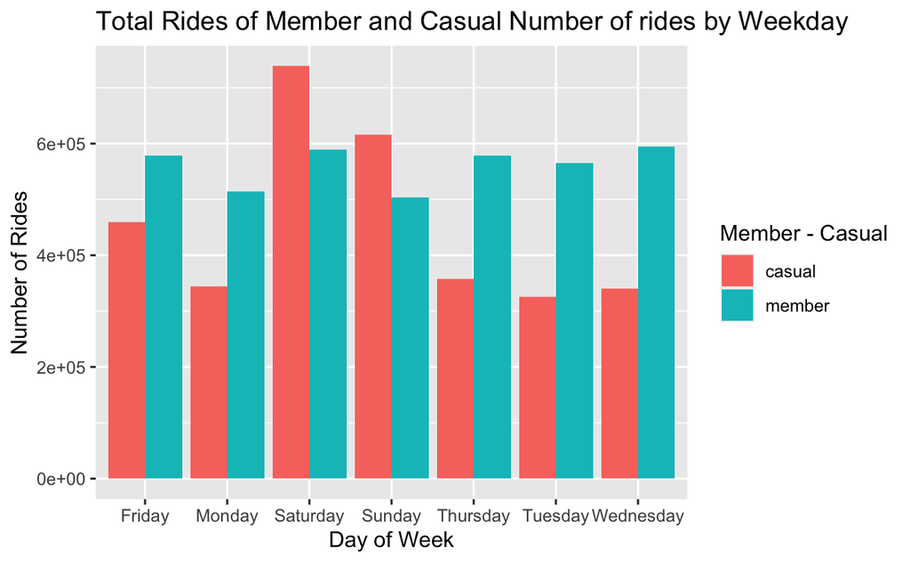

```r
#plot for weekdays
trip_clean %>%
  group_by(member_casual, weekday) %>%
  summarize(count = n(), mean(ride_length)) %>%
  arrange(member_casual, count)  %>%
  ggplot(aes(x=weekday, y=count, fill = member_casual)) +
  geom_bar(stat='identity', position = "dodge") +
  labs(title = "Total Rides of Member and Casual Number of rides by Weekday", x = "Day of Week", y = "Number of Rides", fill = "Member - Casual")
```

## Act

From the above findings, my tops recommendations to the marketing agency would be the following:

- Provide weekend membership specials to casuals
- Encourage membership conversion through special deals on ridership length in April to June (i.e. new members get half off their existing ride) and count from July to August (i.e. members who sign on get free rides for the rest of the month)
- Share clear cost saving benefits of membership usage to specials, encouraging them to get an annual membership and save over renting for each trip. A “You could be saving X dollars!” could do the trick here